# Meta Diversity

Theres something special about those first few days of a new expansion. With new sets come new possibilities, everyone is trying new stuff and your opponents deck could contain anything! But as time goes by, strong decks emerge and start to stomp on your favourite home-brew creations. Within a month you probably know every card in your opponents deck by turn-2 and your playing a [deck you got from the internet](https://hsreplay.net/decks/), not that there’s anything wrong with that ;).

Deck and card diversity in a meta is intrinsically linked to the quality of the play experience. Lower diversity leads to staleness as players grow tired of replaying the same or similar match-ups. So what does deck diversity actualy look like as old sets sun-set and new ones release? With the recent introduction of Knights of the Frozen Throne expansion, theirs probably no better time to look!

In the following article, we borrow concepts from ecological science of al things to track diversity in the cards that people queue up with. This leads us to into presenting a first purely objective insight into how players ‘work out’ the meta and congregate toward common play-styles.

## Tracking Diversity

Diversity in a population can be measured using the [“Shannon Index”](https://en.wikipedia.org/wiki/Diversity_index#Shannon_index). Drawing on the ecology analogy, in our study we treat each card as a species *i* and its frequency of inclusion in decks as its dominance on the population *p*. The result is an objective measure of the diversity of play *H’* (which we can track over time).

Figure 1: Shannon Index (Meta Diversity) by date for the meta as a whole. Derived from 3.75 Billion card-includes in Standard decks played since January 2017. Key dates outlined (Patches & Content releases solid, Season resets dashed, STB = Small Time Buccaneer).

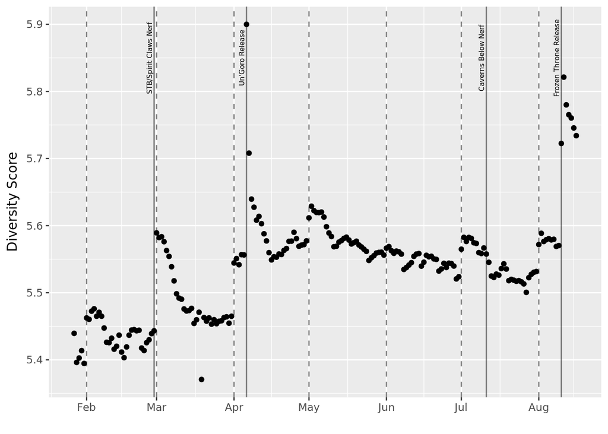

The diversity metric appears to be sensitive enough to detect shifts in the meta diversity, with trends following a fairly logical trajectory. The following represents a few insights that are evident from the figure:

- Major content releases drive massive spikes in deck diversity.
- The STB/Spirit Claws nerf temporarily improved meta diversity but it quickly reverted.
- The Caverns Below nerf had little overall effect on meta diversity.
- Periods between a season reset and a content release or nerf see enhanced deck diversity.
- The Frozen Throne meta is more diverse than ever, which might be expected given the higher card count.
- The Un’Goro meta never really “stabilized”, in stark contrast to MSoG. Deck diversity continued on a downward trajectory right up until the KOFT realease.

Perhaps the most important observation is that deck diversity was consistently higher during Un’Goro compared to MSoG, despite there being less total cards to play with! Such an achievement is probably another reason why the Un’Goro meta was regarded so highly, with player sentiment not dipping to the lows it saw toward the end of MSoG.

## Breaking it Down

Of course, a meta is as much about the inter-play between the classes as anything else. The following shows the above plot broken down by class.

Figure 2: Shannon Index (Meta Diversity) by date and player class. Derived from 3.75 Billion card-includes in Standard decks played since January 2017. Key dates outlined (Patches & Content releases solid, Season resets dashed, STB = Small Time Buccaneer).

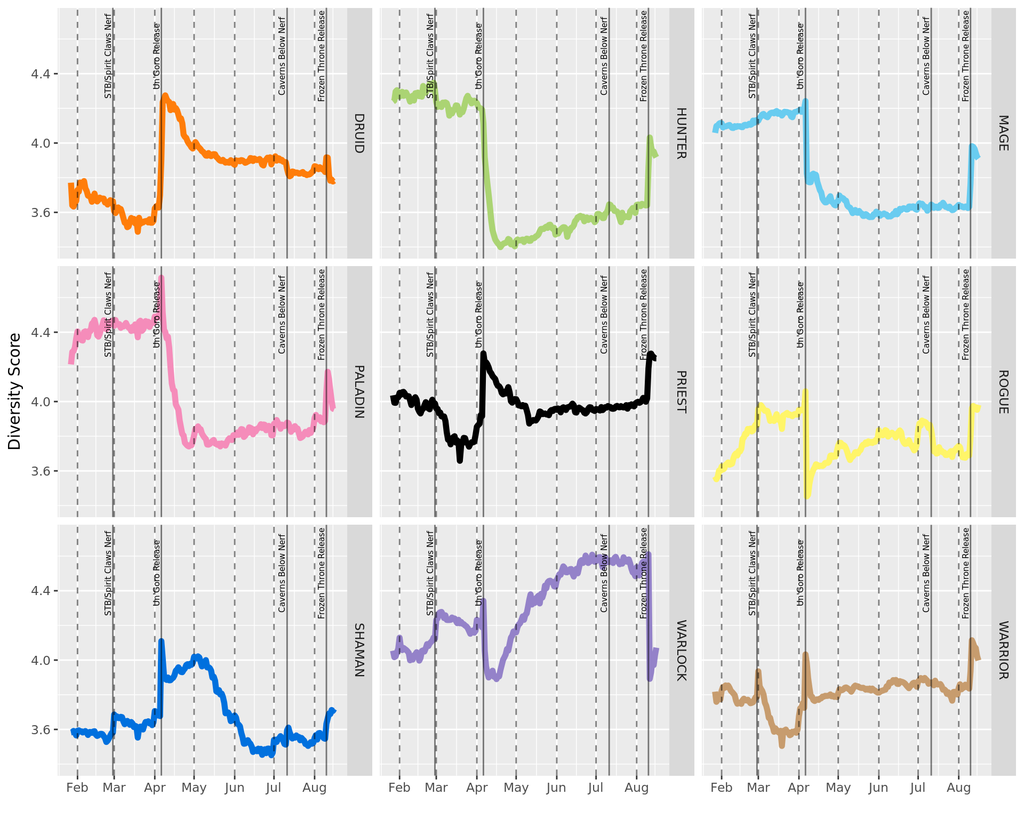

[figure not shown]

A classes diversity appears to be linked to its competitive viability particularly once the meta begins to settle. MSoG era Paladin and Hunter, and Un’Goro Warlock saw some of the highest diversity ever seen. This is likely due to players continuing to test and try to find competitive builds, or because there being played by players less knowledgeable about the overall meta.

The low points of diversity represent period where single powerful archetypes were dominant. For example, Jade druid post the [nerf to shaman](https://hsreplay.net/articles/5/shaking-meta-patch-71-numbers) became incredibly popular among Druid players. Hunter has seen little in the way of viable archetypes other than mid-range, and Un’Goro provided enough tools for players to gravitate back to it. Shaman has typically seen some of the lowest diversity in actual play, despite its richness in viable archetypes particularly during the year of the Kraken.

Very early signs in the KOFT meta point to strong diversity in priest builds, with archetypes like Resurrect, Ramp, Control and Highlander being popular. Druid and Shaman see the least diversity, with druid builds starting to homogenize the Token, Ramp and Jade archetypes into single decks! Evolve shaman is also seeing significant play, which is unsurprising given how obviously the Trall Deathseer hero fits into that already strong build.